# Module 3 Assignment

Nikhil Rochlani

30/01/2022

## Introduction:

In this module assignment, We are first going to build a multiple linear regression model for predicting our response variable i.e. SalePrice of house .We will introduce most relevant variables which can be taken into consideration to predict the SalePrice.

Now for the fitted model we are going to test its:

*Normality*  
-> By creating the residual plot

-> By creating a density plot for Residuals

-> We will compare Residual plots : Fit_1 v/s Fit2

*Going to Identify the outliers:*

-> We will create one qq-plot for fitted model to check the distribution of the residuals against the Quantiles.

-> Then we will look at the top 5 outliers present in model

*Evaluation of Model:*

-> We will check if there is multicollinearity present or not

## Multiple Linear Regression Model: SalePrice ~ First floor Sf + Overall_Qual + General Living area Sf

**Interpretation of the Model:**

As we can see here our response variable is SalePrice and the explanatory variables are First floor s.f, General Living area s.f, and Overall quality of house.

*Selection of variables:*

Basically before building a regression model one should always check the correlation between the explanatory variable and the response varibale to check if there is an underlying correlation or not, Let it be a positive or a negative. Here, We have selected three independent variables which were positively correlated with the SalePrice of the house.

*Interpretation of the Summary of the Model:*

As We can look at the summary ofour model we can see some things which tells us about the reliability of our model. Some values which are very important that are T-statistic value, R-squared value and p-value,etc

The R-squared value is also known as the sum of squared errors. Basically the distance between the y(original value) and y-hat value(predicted) is termed as error(residual value). So we square these errors to get positive numbers.

Now for our model, The r-squared value is 0.758 which is highly significant value and which also tells us that we can rely on this model for prediction of values for dependent variable.

*Augmented Model:*

As we can see after augmenting the model, We get certain values which we can’t see in the summary of our model. Basically One can see the fitted values, residual values , hat values and cooks distance value.

SalePrice -> Original Values

Fitted value -> Predicted Value

Residual Value -> SalePrice - Fitted Values

hat value -> This is taken into consideration to check “Leverage”

Cooks Distance -> This is taken into consideration to check “Influence”

```r
fit_1 <-lm(data_reg$SalePrice ~ data_reg$X1st.Flr.SF+ data_reg$Overall.Qual+ data_reg$Gr.Liv.Area, data = data_reg)

summary(fit_1)
```

```
  Call:
  lm(formula = data_reg$SalePrice ~ data_reg$X1st.Flr.SF + data_reg$Overall.Qual +
      data_reg$Gr.Liv.Area, data = data_reg)

  Residuals:
      Min      1Q  Median      3Q     Max
  -473080  -20922    -781   18954  274988

  Coefficients:
                          Estimate Std. Error t value Pr(>|t|)
  (Intercept)           -1.210e+05  3.302e+03  -36.64   <2e-16 ***
  data_reg$X1st.Flr.SF   4.160e+01  2.299e+00   18.09   <2e-16 ***
  data_reg$Overall.Qual  3.055e+04  6.431e+02   47.51   <2e-16 ***
  data_reg$Gr.Liv.Area   4.491e+01  1.907e+00   23.55   <2e-16 ***
  ---
  Signif. codes:  0 '***' 0.001 '**' 0.01 '*' 0.05 '.' 0.1 ' ' 1

  Residual standard error: 39240 on 2926 degrees of freedom
  Multiple R-squared:  0.759,   Adjusted R-squared:  0.7588
  F-statistic:  3072 on 3 and 2926 DF,  p-value: < 2.2e-16
```

```r
augmented_fit_1 <-fit_1%>%
  augment()%>%
  sample(size = 10)

col_order <- c("data_reg$SalePrice", ".fitted", ".resid", ".hat", ".cooksd")

augmented_fit_1 <- augmented_fit_1[, col_order]
augmented_fit_1
```

```
  # A tibble: 2,930 x 5
     `data_reg$SalePrice` .fitted  .resid     .hat    .cooksd
                    <int>   <dbl>   <dbl>    <dbl>      <dbl>
   1               215000 205570.   9430. 0.00110  0.0000159
   2               105000 109271.  -4271. 0.000833 0.00000247
   3               172000 177281.  -5281. 0.000574 0.00000260
   4               244000 275396. -31396. 0.00247  0.000397
   5               189900 143521.  46379. 0.000936 0.000328
   6               195500 172866.  22634. 0.000609 0.0000507
   7               213500 239160. -25660. 0.00161  0.000172
   8               191500 234142. -42642. 0.00172  0.000508
   9               236500 263210. -26710. 0.00141  0.000164
  10               189000 216641. -27641. 0.000802 0.0000996
  # ... with 2,920 more rows
```

## Residual Plots

Residual plots are normally used to visualise the distribution followed by the Residuals for the given model. It is important to assess the distribution followed by the residuals because that helps us to know whether our model is linear or non-linear

**Residual Plot with high coefficient and t-statistic value: Fitted Model**

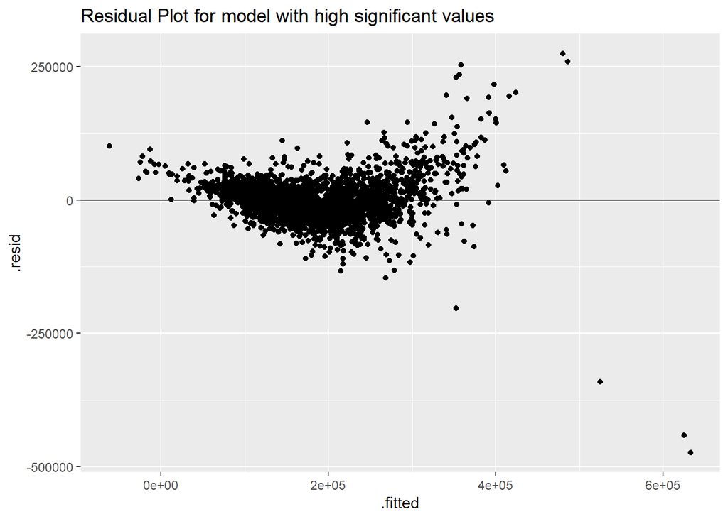

```r
res_plot_1 <- ggplot(augmented_fit_1, aes(x = .fitted, y= .resid))+
  geom_point() + geom_hline(yintercept = 0)+ ggtitle("Residual Plot for model with high significant values")
res_plot_1
```

## Multiple Linear Regression Model-2: SalePrice ~ Fireplace + Wood.deck

This model is build to create a residual plot for model which has independent variables which cannot be considered to predict the value for SalePrice.

As we can see the R-squared value for this model is 0.27 which is not significant enough to rely on.

And we can also see the fitted values in the augmented model, The fitted values are much deviated from the original values which results in getting much more error(residuals)

```r
fit_2 <-lm(data_reg$SalePrice ~ data_reg$Fireplaces+ data_reg$Wood.Deck.SF, data = data_reg)

summary(fit_2)
```

```
  Call:
  lm(formula = data_reg$SalePrice ~ data_reg$Fireplaces + data_reg$Wood.Deck.SF,
      data = data_reg)

  Residuals:
      Min      1Q  Median      3Q     Max
  -207845  -42434  -10002   30066  480066

  Coefficients:
                         Estimate Std. Error t value Pr(>|t|)
  (Intercept)           135933.69    1843.71   73.73   <2e-16 ***
  data_reg$Fireplaces    52018.07    1991.97   26.11   <2e-16 ***
  data_reg$Wood.Deck.SF    145.99      10.21   14.29   <2e-16 ***
  ---
  Signif. codes:  0 '***' 0.001 '**' 0.01 '*' 0.05 '.' 0.1 ' ' 1

  Residual standard error: 68010 on 2927 degrees of freedom
  Multiple R-squared:  0.2758,  Adjusted R-squared:  0.2753
  F-statistic: 557.2 on 2 and 2927 DF,  p-value: < 2.2e-16
```

```r
augmented_fit_2 <-fit_2%>%
  augment()

col_order <- c("data_reg$SalePrice", ".fitted", ".resid", ".hat", ".cooksd")

augmented_fit_2 <- augmented_fit_2[, col_order]
augmented_fit_2
```

```
  # A tibble: 2,930 x 5
     `data_reg$SalePrice` .fitted  .resid     .hat    .cooksd
                    <int>   <dbl>   <dbl>    <dbl>      <dbl>
   1               215000 270628. -55628. 0.00200  0.000448
   2               105000 156373. -51373. 0.000753 0.000143
   3               172000 193309. -21309. 0.00303  0.0000997
   4               244000 239970.   4030. 0.00249  0.00000292
   5               189900 218902. -29002. 0.000699 0.0000425
   6               195500 240509. -45009. 0.00186  0.000273
   7               213500 135934.  77566. 0.000735 0.000319
   8               191500 135934.  55566. 0.000735 0.000164
   9               236500 222552.  13948. 0.000827 0.0000116
  10               189000 208391. -19391. 0.000490 0.0000133
  # ... with 2,920 more rows
```

**Residual Plot with low coefficient and t-statistic value**

After having look at this residual plot, We can clearly see the difference between the ftted and the less significant model. As there are so many outliers present in this residual plot it explains that the normality doesn’t exists.

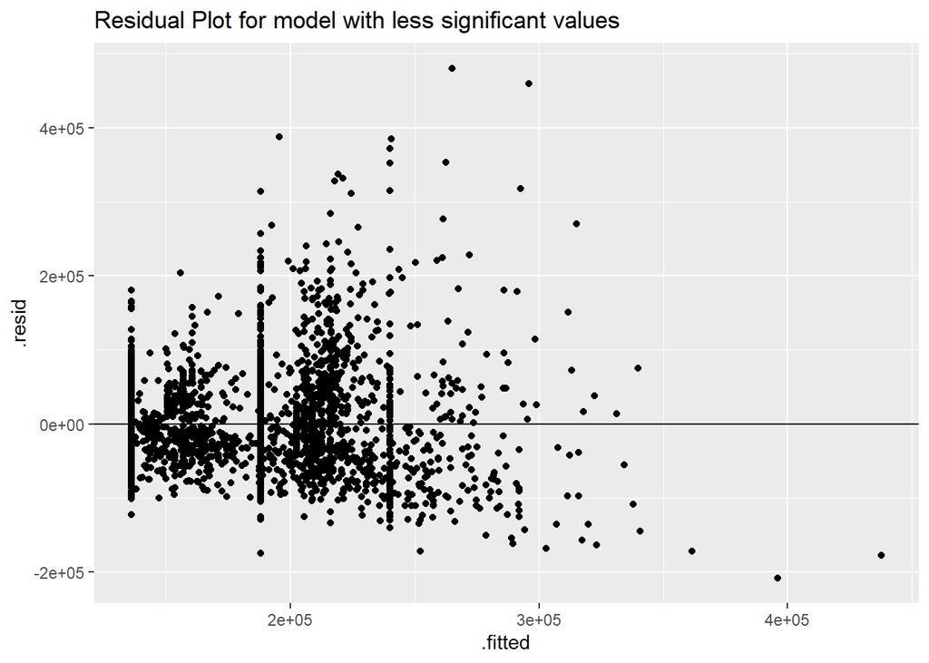

```r
res_plot_2 <- ggplot(augmented_fit_2, aes(x = .fitted, y= .resid))+
  geom_point() + geom_hline(yintercept = 0) + ggtitle("Residual Plot for model with less significant values")
res_plot_2
```

### Density plot for residuals

Density plots are also a good option to check the distribution of the residuals of a specific model.

## Fitted Model

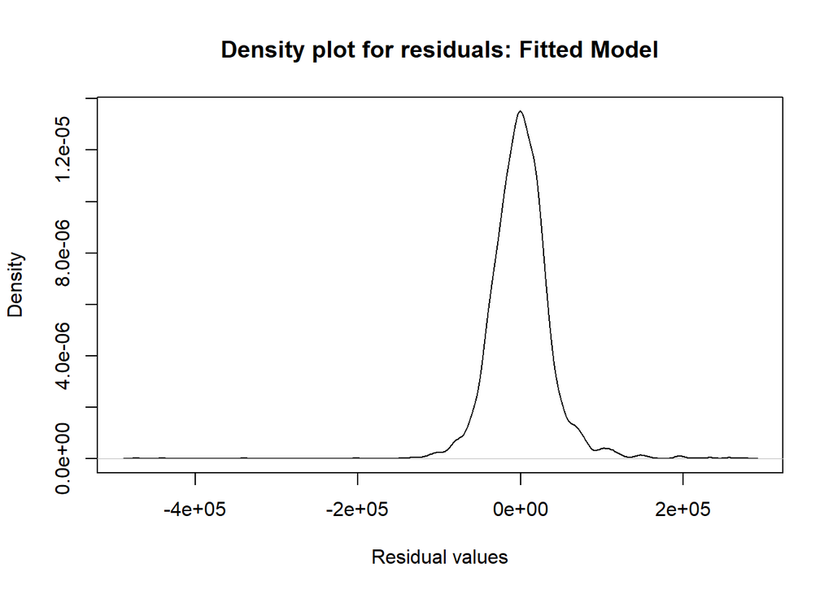

```r
plot(density(residuals(fit_1)), main = "Density plot for residuals: Fitted Model", xlab="Residual values")
```

## Model with less significant values

The residual plot should have the residual plotted against the fitted values to get better understanding of its distribution.

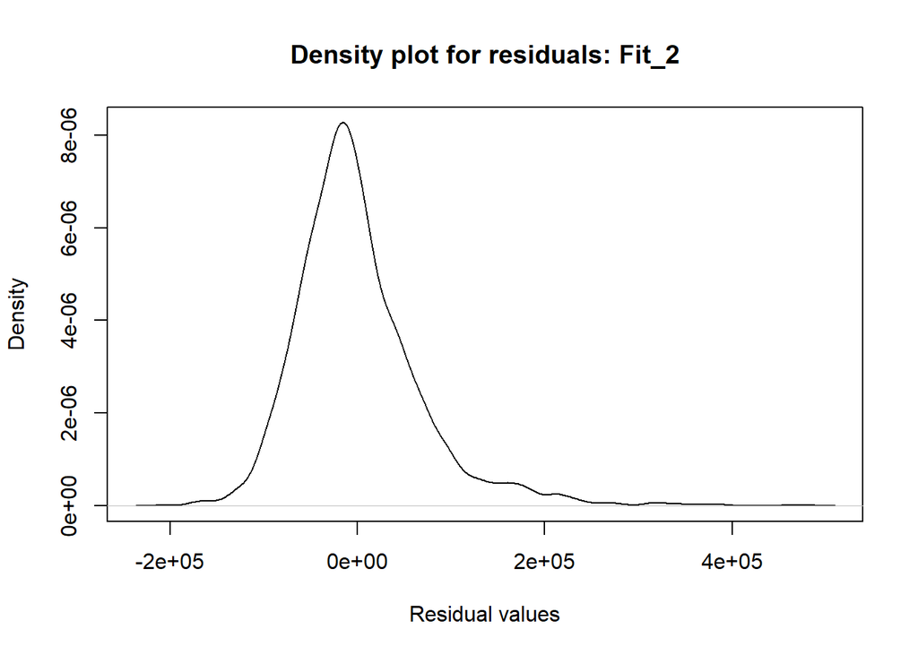

```r
plot(density(residuals(fit_2)), main = "Density plot for residuals: Fit_2", xlab="Residual values")
```

## QQplot for fitted model and its interpretation

There are multiple ways to create the qqplot in r there are various base packages and also we can use ggplotvto create one.

But, As we have a look on this qq-plot we can clearly see the root-cause to generate one. 1) To see the distribution followed by the variables

2. To determine outliers

Now we can see there are 2-3 data-points which are labeled with the numbers that are outliers present in the residuals.

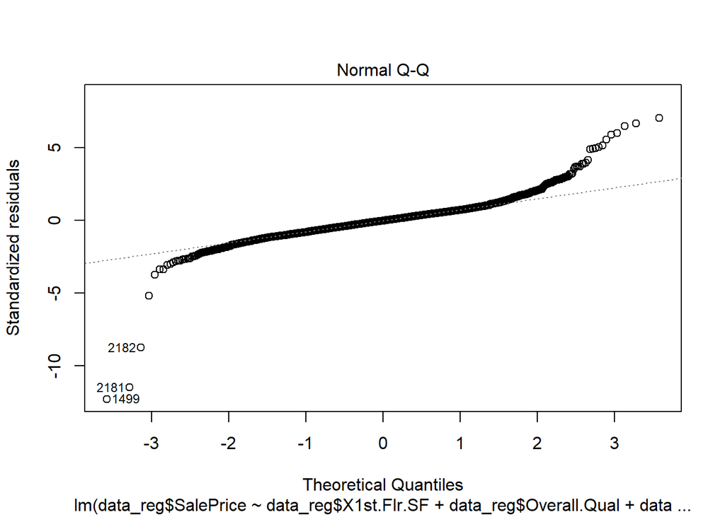

```r
plot(fit_1, which = 2)
```

## Identifying Top-5 Outliers

There are two ways demonstrated below in which we can determine the top 5 outliers:

1. In the first method I have sorted the residuals manually from the fitted model and then arranged them in a descending order to get the top 5 residual values which can be termed as outliers. In this output we get the index position of the outlier with its residual value.
2. In the second method I have used the function which is available in R to determine the outliers. We can see there is a little difference in both outputs as there are certain numbers of things which are considered in determining the outliers through “outlierTest” function.

```r
outliers_fit1 <- sort(residuals(fit_1), decreasing = TRUE)
top_5 <-head(outliers_fit1, n=5)
top_5
```

```
      1768     1761       45     1638      434
  274988.1 259175.4 253187.0 235366.3 230102.9
```

```r
outlierTest(fit_1, n=5)
```

```
         rstudent unadjusted p-value Bonferroni p
  1499 -12.617580         1.4034e-35   4.1121e-32
  2181 -11.746019         3.6684e-31   1.0748e-27
  2182  -8.856700         1.4000e-18   4.1020e-15
  1768   7.106784         1.4860e-12   4.3541e-09
  1761   6.696139         2.5560e-11   7.4890e-08
```

## Evaluation Multicollinearity in the Fitted model

For building a good regression model one thing should be certain in the mind that the independent variables should be correlated with each other. If they are correlated it means there is presence of multicollinearity in the model

Because the regression model shows us the variablity in the dependent variable with 1 unit change in the independent variable with other independent variable being constant.

Therefore, The multicollinearity is term where we check the correlation of the independent variables with each other.

So, The basic idea is to calculate “Variance Inflation Factor” which tells us the factor by which correlation between predictors affect the variance. So the VIF should be less than 5, In order to eliminate risk of multicollinearity.

```r
vif(fit_1)
```

```
   data_reg$X1st.Flr.SF data_reg$Overall.Qual  data_reg$Gr.Liv.Area
               1.544684              1.566449              1.767307
```

## Refernce:

1. A. (2021a, February 18). Multicollinearity: Problem, Detection and Solution. Analytics Vidhya. https://www.analyticsvidhya.com/blog/2021/02/multicollinearity-problem-detection-and-solution/
2. Z. (2021c, April 22). How to Create a Residual Plot in R. Statology. https://www.statology.org/residual-plot-r/
3. Correlation and Regression in R [DataCamp]